# Week 2 CompRtition

Author

218252

# Visit Sussex

[figure not shown]

Falmer House at The University of Sussex

A leading research institution, located in the beautiful and scenic South Downs National Park, what better place to study than [The University of Sussex](https://www.sussex.ac.uk/). From scientific discovery to global policy, from student welfare to career development, Sussex innovates and takes a lead. There are so many reasons to visit Sussex.

## Beautiful and Scenic

Sussex campus is located in the South Downs National park and offers stunning views of the rolling hills and beautiful green spaces.

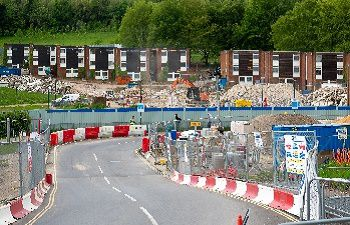

Example of the awe inspiring views on campus

## Management, Staff and Student Partnership

Academia is as thriving as it has always been as exemplified by the passionate lecturers at Sussex

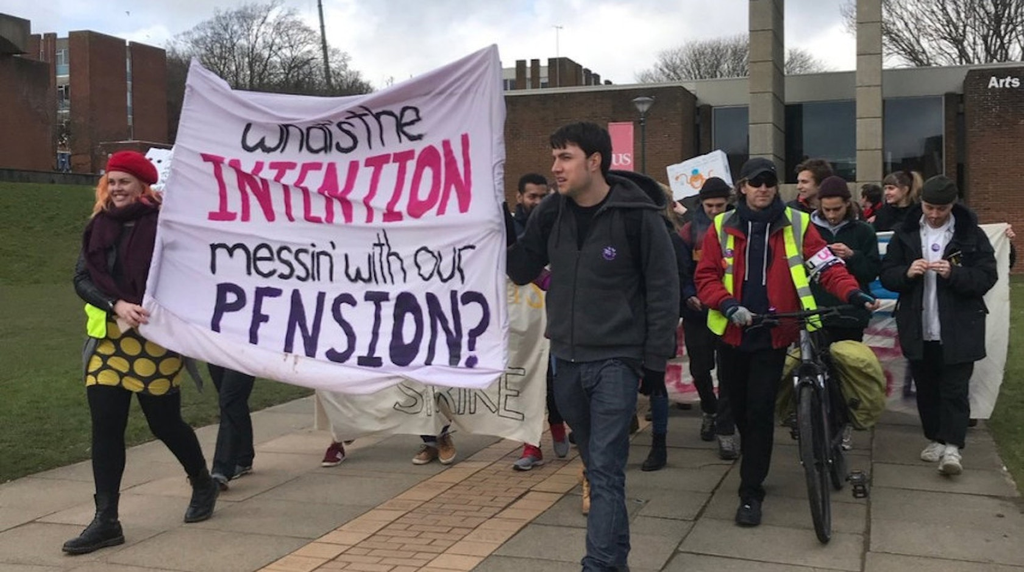

Sussex staff teaching students about participating in collective action

**Good to know!**

Sussex contributes to open science by paying to publish in big-name journals and also paying to access them! For example, access to articles such as Fortunato and Galassi (2021) are included in my tuition fee!

## Great Value Food

Sussex offers many food options that anyone would be envious of.

[figure not shown]

Mouthwatering food options - Only £25!

## Loving Sussex Just Makes Sense!

$\text{Loving Sussex}=\hat{b}_{StockholmSyndrome}+\hat{b}_{SunkCostFallacy}+\varepsilon$

Who could argue with maths like that?

## We Have Data To Prove It

I made up this data and presented it using Wickham et al. (2019):

```r
library(readr)
library(kableExtra)

df <- readxl::read_excel('/cloud/project/data/FakeSussexLoveData.xlsx')
colnames(df)[1] <- "Participant"

df |>
  dplyr::sample_n(20) |>
  knitr::kable(caption = "Data of student's love for their university", digits = 2) |>
  kable_classic(full_width = F, html_font = "Cambria")
```

Data of student's love for their university

| Participant | University | Love For Their University | Asked at gunpoint |
| --- | --- | --- | --- |
| 15 | Other University | 2 | No |
| 4 | Sussex | 7 | Yes |
| 17 | Other University | 1 | No |
| 7 | Sussex | 6 | Yes |
| 10 | Sussex | 7 | Yes |
| 9 | Sussex | 7 | Yes |
| 12 | Other University | 3 | No |
| 2 | Sussex | 7 | Yes |
| 1 | Sussex | 6 | Yes |
| 3 | Sussex | 5 | No |
| 18 | Other University | 1 | No |
| 20 | Other University | 1 | No |
| 19 | Other University | 3 | No |
| 16 | Other University | 3 | No |
| 6 | Sussex | 7 | Yes |
| 14 | Other University | 4 | No |
| 13 | Other University | 1 | No |
| 5 | Sussex | 6 | Yes |
| 11 | Other University | 2 | No |
| 8 | Sussex | 5 | No |

And ran a T test on the data:

```r
colnames(df)[3] <- "university_love"
df$University <- as.factor(df$University)
t.test(university_love~University, data=df)
```

```
    Welch Two Sample t-test

data:  university_love by University
t = -9.6638, df = 16.671, p-value = 3.046e-08
alternative hypothesis: true difference in means between group Other University and group Sussex is not equal to 0
95 percent confidence interval:
 -5.118335 -3.281665
sample estimates:
mean in group Other University           mean in group Sussex
                           2.1                            6.3
```

A significant p value means it’s true. Right?

## Finally, a message from me:

Everything in the above document was intended to be a light-hearted parody and no ill intent or malice went into making it. I love Sussex and consider myself very lucky to be able to study here.

> No act of kindness,

> no matter how small,

> is ever wasted.

> -Aesop

💙💖🤍

## References

Fortunato, Laura, and Mark Galassi. 2021. “The Case for Free and Open Source Software in Research and Scholarship.” *Philosophical Transactions of the Royal Society A: Mathematical, Physical and Engineering Sciences* 379 (2197). https://doi.org/10.1098/rsta.2020.0079.

Wickham, Hadley, Mara Averick, Jennifer Bryan, Winston Chang, Lucy D’Agostino McGowan, Romain François, Garrett Grolemund, et al. 2019. “Welcome to the Tidyverse” 4: 1686. https://doi.org/10.21105/joss.01686.